# Primary_Rating_Analysis

Niklas

2024-10-21

## Primary Rating Analysis

Here I will describe and evaluate our measurement of rating specific touch actions.

This document will have 3 segments:

-Descriptive Statistics

-Validity Check (Through (Sediment) and Frequency)

-Explorativ (Role, Specific Touch)

# Summary of Variable and Histogram

Here is an overview over the variable “Rating” and its distribution.

```
##    Min. 1st Qu.  Median    Mean 3rd Qu.    Max.    NA's
## -100.00    6.75   51.50   41.41   84.25  100.00    1805
```

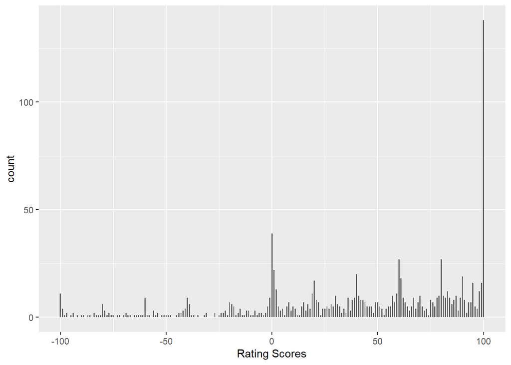

## Validity Check

In this section, I want to investigate how well rating actually is related to other concept, to prove its convergent validity.

1. Frequency How is the rating related to Frequency.

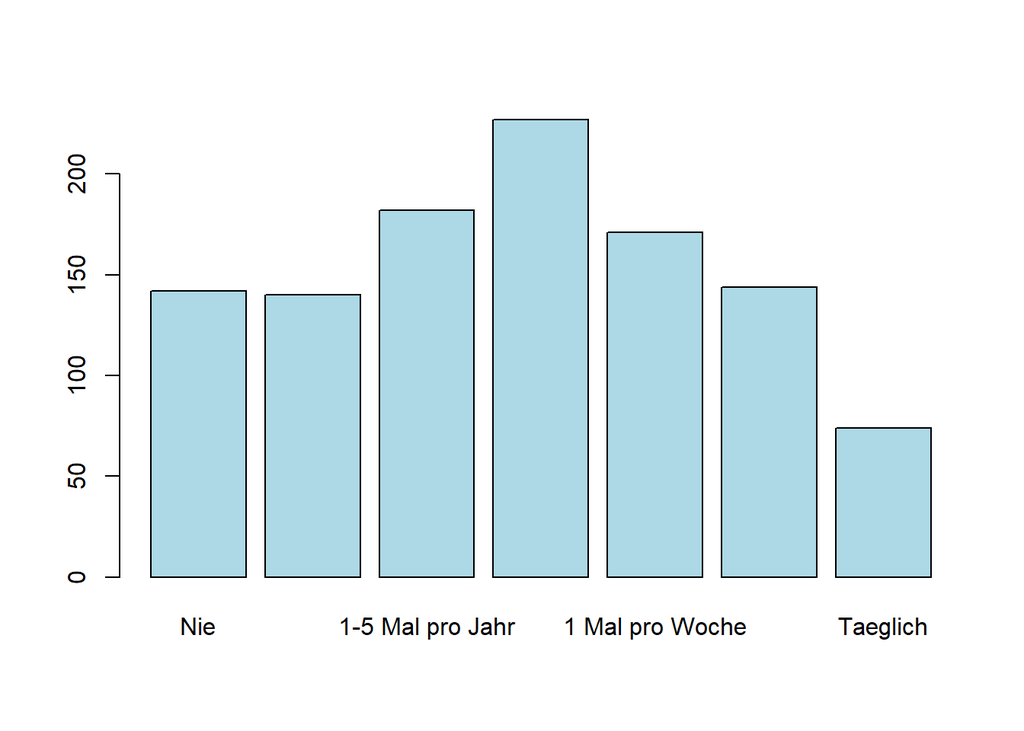

```r
plot(reduceddata$freq_1, col = "lightblue")
```

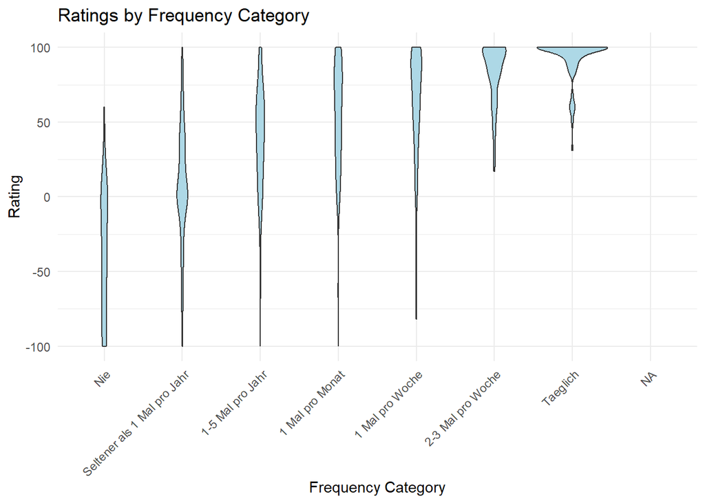

```r
ggplot(reduceddata, aes(x = freq_1, y = rating_1)) +
  geom_violin(na.rm = TRUE, fill = "lightblue") +
  labs(title = "Ratings by Frequency Category",
       x = "Frequency Category",
       y = "Rating") +
  theme_minimal() +
  theme(axis.text.x = element_text(angle = 45, hjust = 1))
```

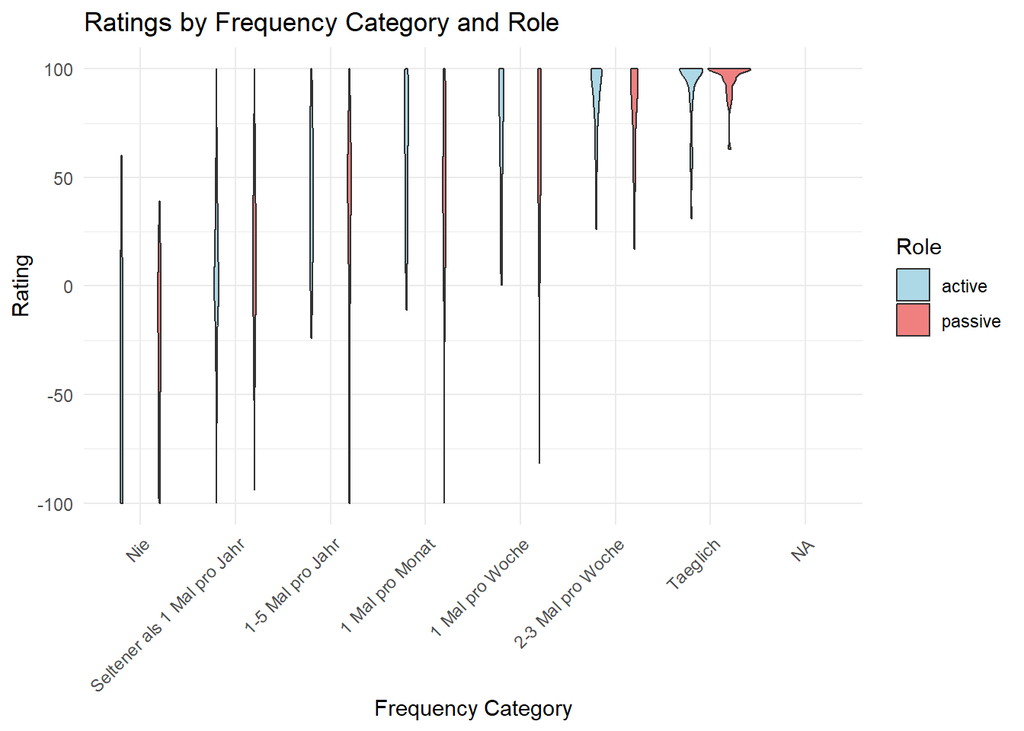

```r
ggplot(reduceddata, aes(x = freq_1, y = rating_1, fill = Role)) +
  geom_violin(na.rm = TRUE, position = position_dodge(0.8)) +
  labs(title = "Ratings by Frequency Category and Role",
       x = "Frequency Category",
       y = "Rating") +
  theme_minimal() +
  theme(axis.text.x = element_text(angle = 45, hjust = 1)) +
  scale_fill_manual(values = c("lightblue", "lightcoral"))
```

```r
paste("Spearman Correlation of", round(cor(reduceddata$rating_1, as.numeric(reduceddata$freq_1), method = "spearman", use = "complete.obs"), 2), "between Rating and Frequency")
```

```
## [1] "Spearman Correlation of 0.73 between Rating and Frequency"
```

The measurement of rating seems valid, as there is a strong relation between Frequency and Rating, as people engage more in touches that are pleasant. A further analysis on rating and sediment could be helpful to verify the validity of rating. A follow-up on this is at the end with word clouds, presenting the “high rated” Adjectives.

# Investigating research relevant variables

In this section, I try to visualize the relationship between the Rating and the variables relevant to our research question (like Role or Specific Touch)

## Rating across Roles

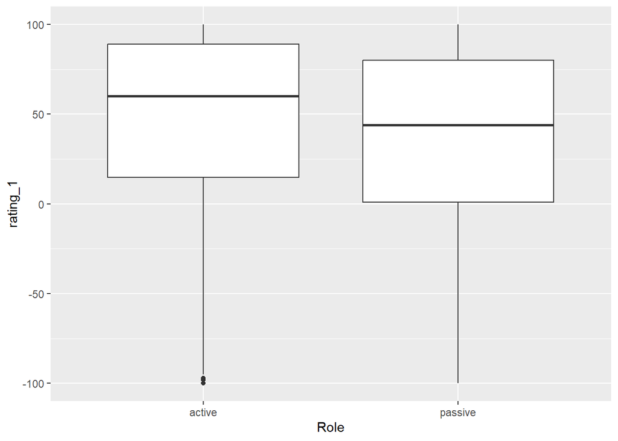

```r
ggplot(reduceddata, aes(x = Role, y = rating_1)) +
  geom_boxplot(na.rm = TRUE)
```

```r
# Calculate descriptive statistics for rating_1 by Role
descriptives <- reduceddata %>%
  group_by(Role) %>%
  summarise(
    Mean = mean(rating_1, na.rm = TRUE),
    Median = median(rating_1, na.rm = TRUE),
    SD = sd(rating_1, na.rm = TRUE),
    IQR = IQR(rating_1, na.rm = TRUE),
    Q1 = quantile(rating_1, 0.25, na.rm = TRUE),
    Q3 = quantile(rating_1, 0.75, na.rm = TRUE),
    Count = n()
  )

kable(descriptives, caption = "Rating Scores in the different Roles")
```

Rating Scores in the different Roles

| Role | Mean | Median | SD | IQR | Q1 | Q3 | Count |
| --- | --- | --- | --- | --- | --- | --- | --- |
| active | 45.48188 | 60 | 51.19036 | 74.25 | 14.75 | 89 | 1455 |
| passive | 37.15530 | 44 | 50.88901 | 79.00 | 1.00 | 80 | 1430 |

```r
##Wilcox Test
wilcox.test(rating_1 ~ Role, data = reduceddata)
```

```
##
##  Wilcoxon rank sum test with continuity correction
##
## data:  rating_1 by Role
## W = 161429, p-value = 0.002159
## alternative hypothesis: true location shift is not equal to 0
```

## Rating across touch situations (Bodypart and Action)

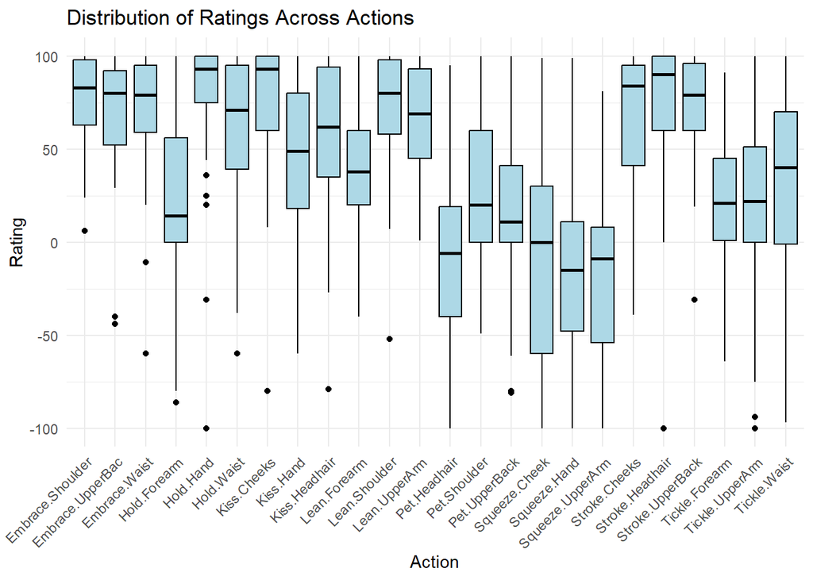

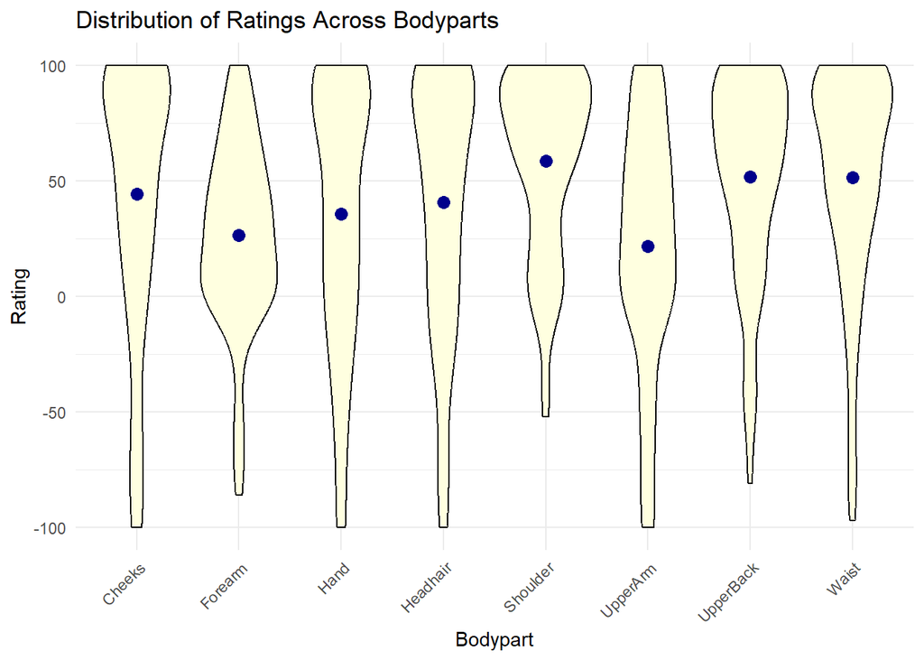

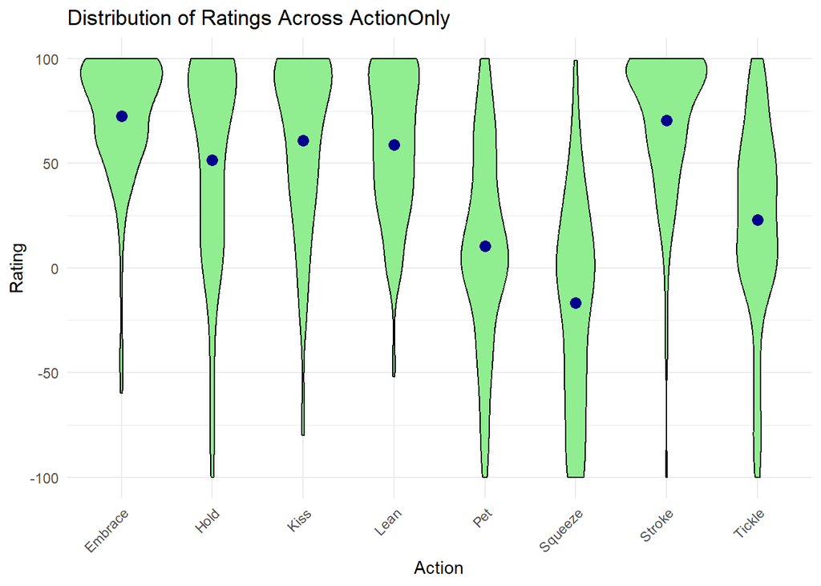

## Add-On: Wordclouds based on Rating

To support the validity of the Rating I created 4 Word-Clouds. One for all touches. And then 3 for touches grouped by low, mid and high rating.

```r
##Create a Word Cloud
general_adj <- (reduceddata$Adjective)

# Subset adjectives for each rating zone
low_ratings_adj <- reduceddata$Adjective[reduceddata$rating >= -100 & reduceddata$rating_1 <= 20]
mid_ratings_adj <- reduceddata$Adjective[reduceddata$rating > 20 & reduceddata$rating_1 <= 80]
high_ratings_adj <- reduceddata$Adjective[reduceddata$rating > 80 & reduceddata$rating_1 <= 100]
```

## All Ratings

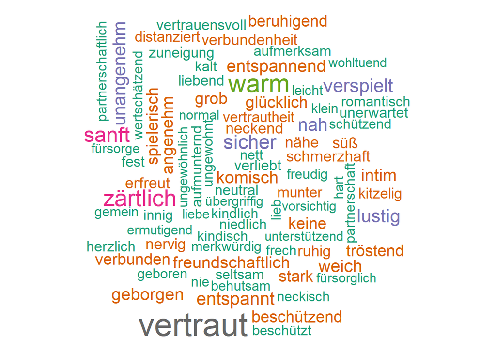

## Low Ratings

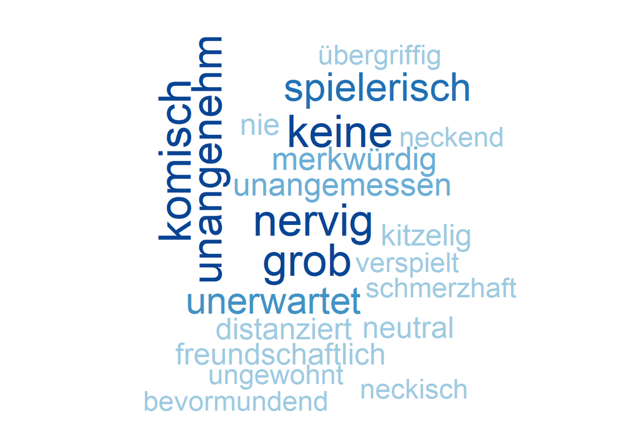

## Mid Ratings

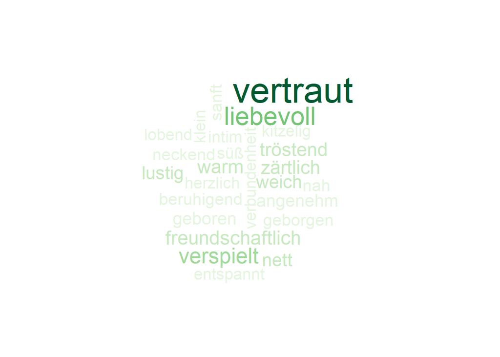

## High Ratings

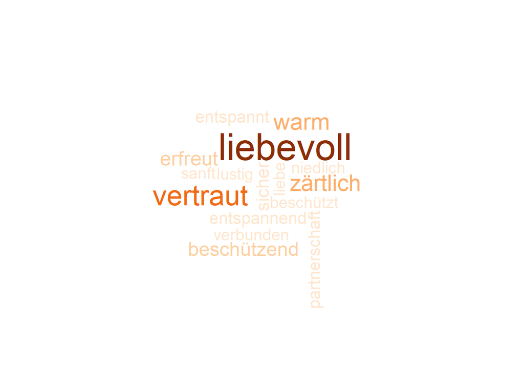